# 城市投资潜力评价分析

中国人民大学 钟保罗

2019-10-30

## 背景介绍

某房地产开发公司拟在长江三角洲、珠江三角洲和环渤海地区中选择具有投资潜力的目标城市进行投资。相关的一系列指标有：系列指标：GDP、人均可支配收入、城市化水平、人均使用面积、户籍人口数量、商品房销售均价、商品房销售面积、商品房施工面积。本次数据分析报告希望通过对备选城市进行综合评价，选出具有投资潜力的城市。

## 变量介绍

本次数据集包含20个城市，包括长江三角洲/珠江三角洲/环渤海地区共20个城市。每个城市由以下8个连续型变量描述

| 变量名 | 单位 | 取值范围 |
| --- | --- | --- |
| 城市 |  | 北京/上海… |
| GDP | 亿元 | 333.2~10297 |
| 人均可支配收入 | 元 | 13350~25320 |
| 城市化水平 |  | 52.00~88.70 |
| 人均使用面积 | 平方米 | 16.50~45.20 |
| 户籍人口数量 | 万人 | 92.63~1368.10 |
| 商品房销售均价 | 元 | 4134~9230 |
| 商品房销售面积 | 万平方米 | 91.8~3025.4 |
| 商品房施工面积 | 万平方米 | 300~10939 |

## 描述统计分析

描述性统计部分通过直方图来观察不同变量的部分情况，并展示每个变量中头部4个城市和尾部4个城市的具体情况进行对比。

### 加载所需的包/数据，设定画图函数/画图主题/画图颜色

```r
library(grid)
library(ggplot2)
library(corrplot)
setwd("F:\\大数据\\大数据统计基础\\L2\\L2")
data = read.csv('城市投资潜力.csv')
head(data)
```

```
##   城市      GDP 人均可支配收入 城市化水平 人均使用面积 户籍人口数量
## 1 深圳  5684.39          22567       83.7         19.7       196.83
## 2 北京  9006.20          21989       84.3         20.1      1213.30
## 3 杭州  3440.99          19027       62.1         21.0       666.31
## 4 上海 10296.97          20668       88.7         16.5      1368.10
## 5 广州  6068.41          19851       69.5         19.4       760.72
## 6 宁波  2864.50          19674       59.0         18.7       560.40
##   商品房销售均价 商品房销售面积 商品房施工面积
## 1           9230         784.63        3122.10
## 2           8792        2176.60       10438.60
## 3           7751         762.50        4545.33
## 4           7038        3025.40       10938.75
## 5           6545        1316.88        5460.37
## 6           5437         601.10        2200.00
```

```r
#
multiplot <- function(..., plotlist=NULL, file, cols=1, layout=NULL) {
  plots <- c(list(...), plotlist)
  numPlots = length(plots)
  if (is.null(layout)) {
    layout <- matrix(seq(1, cols * ceiling(numPlots/cols)),
                     ncol = cols, nrow = ceiling(numPlots/cols))
  }
  if (numPlots==1) {    print(plots[[1]])  }
  else {
    grid.newpage()
    pushViewport(viewport(layout = grid.layout(nrow(layout), ncol(layout))))
    for (i in 1:numPlots) {
      matchidx <- as.data.frame(which(layout == i, arr.ind = TRUE))
      print(plots[[i]], vp = viewport(layout.pos.row = matchidx$row,
                                      layout.pos.col = matchidx$col))
    }
  }
}

mytheme <- theme_bw()+theme(panel.border=element_blank(),panel.grid.major = element_blank(),panel.grid.minor = element_blank())

color_green = '#96ce54'
```

### GDP&人均可支配收入&城市化水平

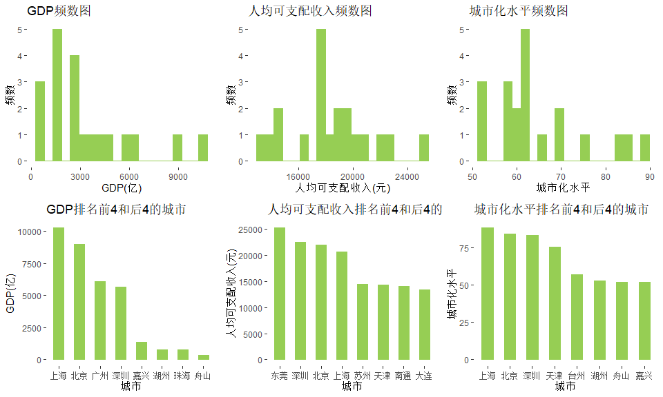

```r
p_1_1 = ggplot(data = data , aes(x = GDP)) +
  geom_histogram(fill = color_green, colour = color_green,bins = 20)+
  labs(title = 'GDP频数图',x = 'GDP(亿)',y = '频数')+mytheme

p_1_2 = ggplot(data = data , aes(x = 人均可支配收入)) +
  geom_histogram(fill = color_green, colour = color_green,bins = 20)+
  labs(title = '人均可支配收入频数图',x = '人均可支配收入(元)',y = '频数')+mytheme

p_1_3 = ggplot(data = data , aes(x = 城市化水平)) +
  geom_histogram(fill = color_green, colour = color_green,bins = 20)+
  labs(title = '城市化水平频数图',x = '城市化水平',y = '频数')+mytheme



data_new = data[order(data[,'GDP'],decreasing = F),c('城市','GDP')][c(1:4,17:20),]
data_new$城市 = factor(data_new$城市,levels = rev(data_new$城市) )
p_2_1 = ggplot(data = data_new , aes(x = 城市,y = GDP))+
  geom_bar(stat = 'identity',width = .5, fill = color_green ,color = color_green)+
  labs(title='GDP排名前4和后4的城市',y = 'GDP(亿)')+mytheme

data_new = data[order(data[,'人均可支配收入'],decreasing = F),c('城市','人均可支配收入')][c(1:4,17:20),]
data_new$城市 = factor(data_new$城市,levels = rev(data_new$城市) )
p_2_2 = ggplot(data = data_new , aes(x = 城市,y = 人均可支配收入))+
  geom_bar(stat = 'identity',width = .5, fill = color_green ,color = color_green)+
  labs(title='人均可支配收入排名前4和后4的城市',y = '人均可支配收入(元)')+mytheme

data_new = data[order(data[,'城市化水平'],decreasing = F),c('城市','城市化水平')][c(1:4,17:20),]
data_new$城市 = factor(data_new$城市,levels = rev(data_new$城市) )
p_2_3 = ggplot(data = data_new , aes(x = 城市,y = 城市化水平))+
  geom_bar(stat = 'identity',width = .5, fill = color_green ,color = color_green)+
  labs(title='城市化水平排名前4和后4的城市',y = '城市化水平')+mytheme

multiplot(p_1_1,p_2_1,p_1_2,p_2_2,p_1_3,p_2_3,cols = 3)
```

### 人均使用面积

1.从人均使用面积来看，东莞人均一骑绝尘，集中在20左右的城市较多，人均使用面积最低的是上海。 2.从户籍人口来看，大城市的人口明显多于其余城市，珠江三角洲的城市人口明显过少，这或许与城市规模/行政面积有关。eg:北京面积约为深圳8倍。超大型城市为北京上海，其余城市仍有较大差距。

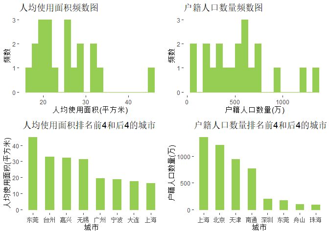

```r
p_1_1 = ggplot(data = data , aes(x = 人均使用面积)) +
  geom_histogram(fill = color_green, colour = color_green,bins = 20)+
  labs(title = '人均使用面积频数图',x = '人均使用面积(平方米)',y = '频数')+mytheme

p_1_2 = ggplot(data = data , aes(x = 户籍人口数量)) +
  geom_histogram(fill = color_green, colour = color_green,bins = 20)+
  labs(title = '户籍人口数量频数图',x = '户籍人口数量(万)',y = '频数')+mytheme


data_new = data[order(data[,'人均使用面积'],decreasing = F),c('城市','人均使用面积')][c(1:4,17:20),]
data_new$城市 = factor(data_new$城市,levels = rev(data_new$城市) )
p_2_1 = ggplot(data = data_new , aes(x = 城市,y = 人均使用面积))+
  geom_bar(stat = 'identity',width = .5, fill = color_green ,color = color_green)+
  labs(title='人均使用面积排名前4和后4的城市',y = '人均使用面积(平方米)')+mytheme

data_new = data[order(data[,'户籍人口数量'],decreasing = F),c('城市','户籍人口数量')][c(1:4,17:20),]
data_new$城市 = factor(data_new$城市,levels = rev(data_new$城市) )
p_2_2 = ggplot(data = data_new , aes(x = 城市,y = 户籍人口数量))+
  geom_bar(stat = 'identity',width = .5, fill = color_green ,color = color_green)+
  labs(title='户籍人口数量排名前4和后4的城市',y = '户籍人口数量(万)')+mytheme

multiplot(p_1_1,p_2_1,p_1_2,p_2_2,cols = 2)
```

### 商品房销售均价/商品房销售面积/商品房施工面积

1.从销售均价来看，深圳/北京/杭州/上海房价较高，其余城市差距不明显，均集中在4000-5000价位附近。 2.从销售面积来看，上海/北京/天津/广州商品房销售面积较高，与其他城市形成明显差距，除以上四个城市外，其余城市商品房销售面积均在1000万平方米以下。 3.从商品房施工面积来看，北京上海为第一梯队，广州苏州约为北上的一半，其余城市施工面积较少。

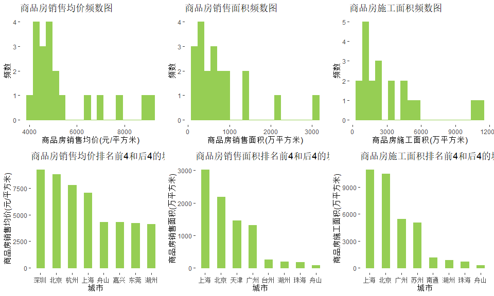

```r
p_1_1 = ggplot(data = data , aes(x = 商品房销售均价)) +
  geom_histogram(fill = color_green, colour = color_green,bins = 20)+
  labs(title = '商品房销售均价频数图',x = '商品房销售均价(元/平方米)',y = '频数')+mytheme

p_1_2 = ggplot(data = data , aes(x = 商品房销售面积)) +
  geom_histogram(fill = color_green, colour = color_green,bins = 20)+
  labs(title = '商品房销售面积频数图',x = '商品房销售面积(万平方米)',y = '频数')+mytheme


p_1_3 = ggplot(data = data , aes(x = 商品房施工面积)) +
  geom_histogram(fill = color_green, colour = color_green,bins = 20)+
  labs(title = '商品房施工面积频数图',x = '商品房施工面积(万平方米)',y = '频数')+mytheme



data_new = data[order(data[,'商品房销售均价'],decreasing = F),c('城市','商品房销售均价')][c(1:4,17:20),]
data_new$城市 = factor(data_new$城市,levels = rev(data_new$城市) )
p_2_1 = ggplot(data = data_new , aes(x = 城市,y = 商品房销售均价))+
  geom_bar(stat = 'identity',width = .5, fill = color_green ,color = color_green)+
  labs(title='商品房销售均价排名前4和后4的城市',y = '商品房销售均价(元/平方米)')+mytheme

data_new = data[order(data[,'商品房销售面积'],decreasing = F),c('城市','商品房销售面积')][c(1:4,17:20),]
data_new$城市 = factor(data_new$城市,levels = rev(data_new$城市) )
p_2_2 = ggplot(data = data_new , aes(x = 城市,y = 商品房销售面积))+
  geom_bar(stat = 'identity',width = .5, fill = color_green ,color = color_green)+
  labs(title='商品房销售面积排名前4和后4的城市',y = '商品房销售面积(万平方米)')+mytheme

data_new = data[order(data[,'商品房施工面积'],decreasing = F),c('城市','商品房施工面积')][c(1:4,17:20),]
data_new$城市 = factor(data_new$城市,levels = rev(data_new$城市) )
p_2_3 = ggplot(data = data_new , aes(x = 城市,y = 商品房施工面积))+
  geom_bar(stat = 'identity',width = .5, fill = color_green ,color = color_green)+
  labs(title='商品房施工面积排名前4和后4的城市',y = '商品房施工面积(万平方米)')+mytheme

multiplot(p_1_1,p_2_1,p_1_2,p_2_2,p_1_3,p_2_3,cols = 3)
```

## 基于主成分分析的城市投资潜力分析

### 相关性检查

从相关系数图看，整体而言，各个变量之间存在较强相关性，人均使用面积几乎与所有变量均呈负相关，说明城市经济水平越高，城市化水平越高，人均可居住面积会随着房价上涨而下降。此外，人均可支配收入预期与变量的相关性均较小，说明影响因素较为复杂。

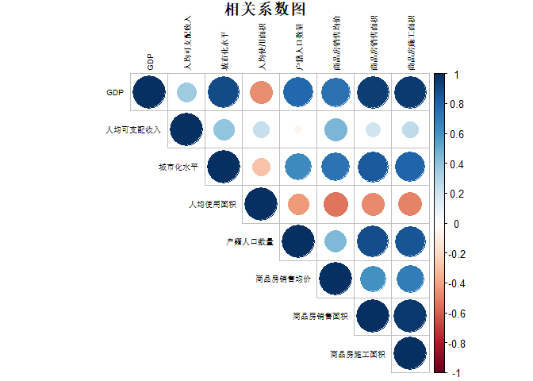

```r
###相关性
data_cor = cor(data[,-1])
corrplot(data_cor,tl.col="black", type = "upper",title="相关系数图",tl.cex=0.6,mar=c(0,0,1,0))
```

### 求解主成分，选择主成分

```r
### 主成分分析
pca.fit = princomp(data[,-1],cor = T)
summary(pca.fit)
```

```
## Importance of components:
##                           Comp.1    Comp.2     Comp.3     Comp.4
## Standard deviation     2.3066692 1.1706703 0.88855356 0.50614733
## Proportion of Variance 0.6650904 0.1713086 0.09869093 0.03202314
## Cumulative Proportion  0.6650904 0.8363990 0.93508992 0.96711306
##                            Comp.5      Comp.6      Comp.7     Comp.8
## Standard deviation     0.40464721 0.259552447 0.152113055 0.09407615
## Proportion of Variance 0.02046742 0.008420934 0.002892298 0.00110629
## Cumulative Proportion  0.98758048 0.996001412 0.998893710 1.00000000
```

```r
data$score1 = round(predict(pca.fit)[,1],2)
data$score2 = round(predict(pca.fit)[,2],2)
```

### 主成分方差贡献率

只挑选前两个主成分累计方差贡献率即可达84%

| 主成分编号 | 标准差 | 方差解释占比 | 方差解释累积占比 |
| --- | --- | --- | --- |
| 1 | 2.31 | 66.51% | 66.51% |
| 2 | 1.17 | 17.13% | 83.64% |
| 3 | 0.89 | 9.87% | 93.51% |
| 4 | 0.51 | 3.20% | 96.71% |
| 5 | 0.40 | 2.05% | 98.76% |
| 6 | 0.26 | 0.84% | 99.60% |
| 7 | 0.15 | 0.29% | 99.89% |
| 8 | 0.09 | 0.11% | 100.00% |

### 碎石图

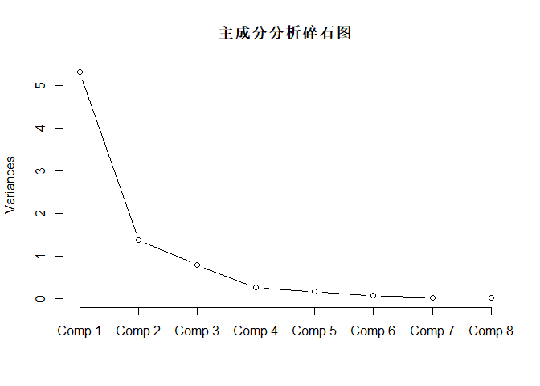

```r
plot(pca.fit,type = 'lines',main = '主成分分析碎石图')
```

### 主成分含义

主成分1主要由GDP/城市化水平/销售面积/施工面积共同决定，因此命名为经济发展水平。主成分2主要由人均可支配收入和人均使用面积决定，命名为人民生活水平。

[output not shown]

### 主成分得分评价

| 城市 | GDP | 人均可支配收入 | 城市化水平 | 人均使用面积 | 户籍人口数量 | 商品房销售均价 | 商品房销售面积 | 商品房施工面积 | score1 | score2 |
| --- | --- | --- | --- | --- | --- | --- | --- | --- | --- | --- |
| 深圳 | 5684.39 | 22567 | 83.7 | 19.7 | 196.83 | 9230 | 784.63 | 3122.10 | 1.90 | 1.95 |
| 北京 | 9006.20 | 21989 | 84.3 | 20.1 | 1213.30 | 8792 | 2176.60 | 10438.60 | 5.29 | 0.70 |
| 杭州 | 3440.99 | 19027 | 62.1 | 21.0 | 666.31 | 7751 | 762.50 | 4545.33 | 0.90 | 0.04 |
| 上海 | 10296.97 | 20668 | 88.7 | 16.5 | 1368.10 | 7038 | 3025.40 | 10938.75 | 6.07 | -0.26 |
| 广州 | 6068.41 | 19851 | 69.5 | 19.4 | 760.72 | 6545 | 1316.88 | 5460.37 | 1.98 | 0.03 |
| 宁波 | 2864.50 | 19674 | 59.0 | 18.7 | 560.40 | 5437 | 601.10 | 2200.00 | -0.27 | -0.17 |
| 天津 | 4337.73 | 14283 | 75.7 | 26.1 | 948.88 | 5013 | 1458.60 | 4271.14 | 1.21 | -1.25 |
| 南京 | 2774.00 | 17538 | 62.1 | 20.4 | 607.23 | 5002 | 932.40 | 3264.44 | -0.03 | -0.71 |
| 苏州 | 4820.26 | 14451 | 62.1 | 20.4 | 615.55 | 4958 | 932.40 | 5058.09 | 0.43 | -1.52 |
| 大连 | 2569.70 | 13350 | 57.5 | 17.5 | 572.10 | 4844 | 628.80 | 2196.10 | -0.72 | -2.05 |
| 珠海 | 749.60 | 17671 | 59.4 | 25.0 | 92.63 | 4731 | 178.88 | 678.55 | -2.04 | 0.09 |
| 台州 | 1467.48 | 19036 | 57.2 | 32.8 | 564.66 | 4726 | 259.72 | 1238.32 | -1.58 | 0.56 |
| 绍兴 | 1678.19 | 19486 | 57.2 | 25.4 | 435.50 | 4500 | 366.00 | 1355.36 | -1.38 | 0.22 |
| 常州 | 1560.00 | 16649 | 62.1 | 28.4 | 354.70 | 4500 | 479.40 | 1701.90 | -1.42 | -0.18 |
| 南通 | 1758.34 | 14058 | 62.1 | 29.4 | 769.79 | 4500 | 473.27 | 1165.86 | -1.18 | -1.13 |
| 无锡 | 3300.00 | 18189 | 70.0 | 31.3 | 457.80 | 4315 | 626.00 | 2322.17 | -0.63 | 0.48 |
| 嘉兴 | 1340.00 | 17828 | 52.0 | 32.1 | 335.50 | 4299 | 359.50 | 1393.70 | -2.08 | 0.21 |
| 舟山 | 333.20 | 17525 | 52.0 | 22.2 | 96.58 | 4299 | 91.80 | 300.00 | -2.49 | -0.34 |
| 东莞 | 2624.63 | 25320 | 65.0 | 45.2 | 168.31 | 4192 | 379.43 | 1431.27 | -1.70 | 3.51 |
| 湖州 | 760.89 | 17503 | 53.0 | 27.0 | 257.89 | 4134 | 195.19 | 887.51 | -2.27 | -0.16 |

### 综合评价图

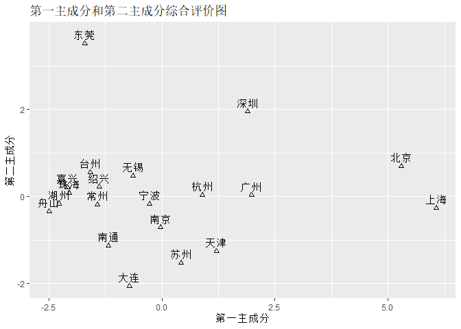

```r
ggplot(data = data,aes(x = score1,y = score2))+geom_point(shape = 2)+
  labs(title = '第一主成分和第二主成分综合评价图',x = '第一主成分',y='第二主成分')+
  geom_text(aes(x = score1,y = score2+0.2,label = 城市))
```